# Лабораторная работа №1

Математические основы защиты информации и информационной безопасности

Мануэл Марсия Педру

Российский университет дружбы народов имени Патриса Лумумбы, Москва, Россия

2026

## Докладчик

- Мануэл Марсия Педру
- Студент группы НФИмд-02-25
- Студ. билет 1032255503
- Российский университет дружбы народов имени Патриса Лумумбы

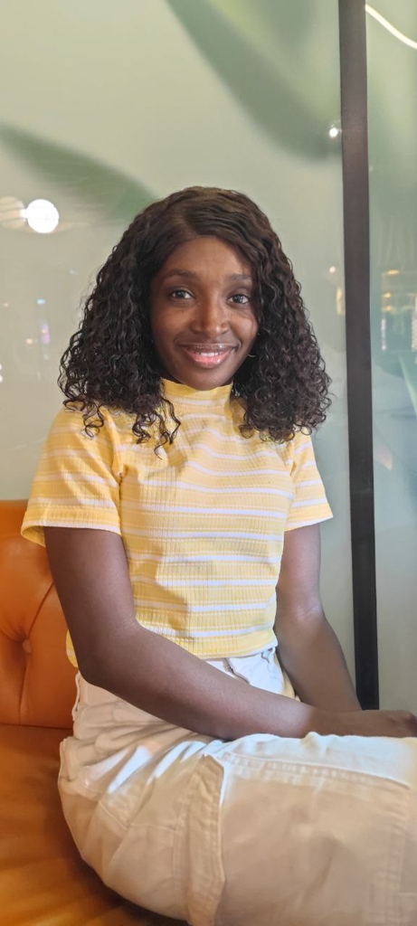

# Цель работы

Изучить шифры простой замены и научиться их реализовывать.

# Выполнение лабораторной работы

Шифр Цезаря — это древнейший шифр подстановки, в котором каждая буква исходного текста заменяется другой буквой, сдвинутой на фиксированное число позиций в алфавите. Этот метод очень прост: например, при сдвиге на 3, А становится Г, Б — Д и так далее. Для восстановления исходного текста нужно сдвинуть буквы в обратном направлении.

## Реализация шифра Атбаш

Шифр Атбаш — это простейший шифр замены, в котором буквы алфавита заменяются в обратном порядке: первая буква становится последней, вторая — предпоследней и так далее. Например, A становится Z, B — Y, а C — X. Этот метод изначально применялся для еврейского алфавита, откуда и получил свое название от первых букв «алеф» и «тав»:

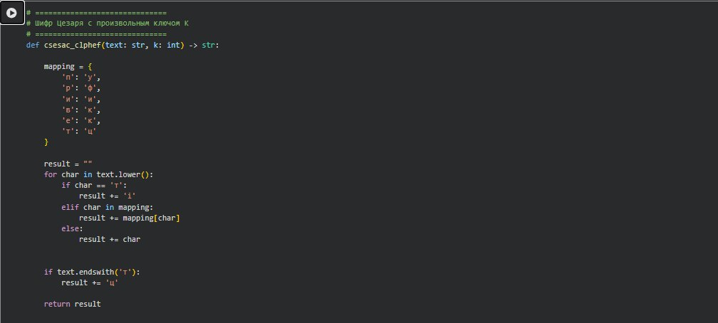

Проверим работу алгоритма (рис. [-@fig:002]):

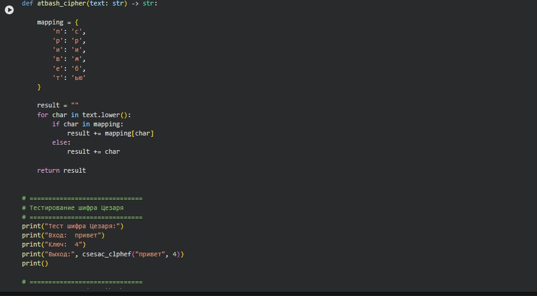

Проверим работу алгоритма (рис. [-@fig:003]):

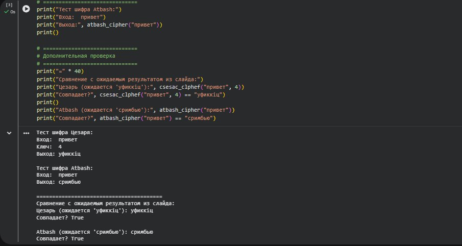

# Вывод